# Case Study:How Does a Bike-Share Navigate Speedy Success?

Thomas Arias

21/3/2022

In this case study a data analysis was made for a fictional company, Cyclistic, a bike-share company in Chicago in order to answer key business questions, mainly:

1. How casual riders and member riders use Cyclistic bikes differently.
2. Design a new marketing strategy to convert casual riders into annual members.

### More info:

Cyclistic’s current marketing strategy relies on building general awareness and appeal to broad consumer segments. One such approach was the flexibility of its pricing plans: single-ride passes, full-day passes and annual memberships. Customers who purchase single-ride passes or full-day passes are considered casual riders, while customers who purchase annual memberships are considered members.

Cyclistic’s financial analysts believe that the largest amount of profit comes from clients who purchase annual memberships, and they want to convert more of their casual clients into annual members. To accomplish this, they need to design a new marketing strategy aimed at casual riders, but first they need to understand how casual and member riders differ. They are interested in analyzing the Cyclistic historical bike trip data to identify potential trends and answer the business questions.

The data was obtained from the Divvy Data website. For more details on the data, click here: [link](https://ride.divvybikes.com/system-data)

[figure not shown]

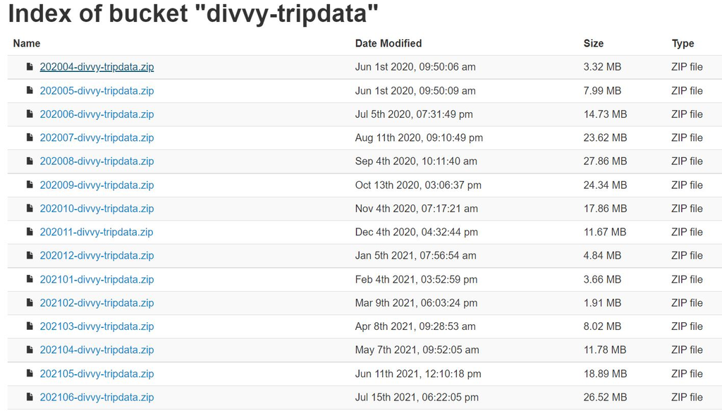

Divvy Data website

Once the data has been downloaded the next step is to clean the data.

### Data cleaning process

$$n_0 = \frac{Z^2 pq}{e^2}$$

Where:

- $n_0 \text{ is the sample size.}$
- $Z^2 \text{ is the critical value of the Z score .}$
- $p \text{ is the percentage of the population that is represented in the formula.}$
- $q \text{ is equal to 1 - p.}$
- $e^2 \text{ is the margin of error squared.}$

### How to read the files

The data is read and loaded into a dataframe called *divvy_trip_data*. The columns for *date_start, time_start, date_end and time_end* are formatted to hours, minutes, day, month and year to use the *Date* function later. A small preview of the data is shown.

```r
#import data from csv file
divvy_trip_data <- read_csv("data/merged_data/divvy-trip-data.csv",
                            col_types = cols(date_start = col_date(format = "%d/%m/%Y"),
                                             time_start = col_time(format = "%H:%M"),
                                             date_end = col_date(format = "%d/%m/%Y"),
                                             time_end = col_time(format = "%H:%M")))
#Small preview of the data along with types
str(divvy_trip_data)
```

```
## spec_tbl_df [7,386 x 12] (S3: spec_tbl_df/tbl_df/tbl/data.frame)
##  $ ride_id       : chr [1:7386] "0449139F2CB5BF9A" "0C4236EB38C3089B" "23D536DF2046804F" "537A084E3D53C9DE" ...
##  $ rideable_type : chr [1:7386] "docked_bike" "docked_bike" "docked_bike" "docked_bike" ...
##  $ date_start    : Date[1:7386], format: "2020-04-01" "2020-04-01" ...
##  $ time_start    : 'hms' num [1:7386] 13:29:00 13:17:00 14:29:00 08:59:00 ...
##   ..- attr(*, "units")= chr "secs"
##  $ date_end      : Date[1:7386], format: "2020-04-01" "2020-04-01" ...
##  $ time_end      : 'hms' num [1:7386] 13:35:00 13:38:00 14:39:00 09:22:00 ...
##   ..- attr(*, "units")= chr "secs"
##  $ end_station_id: chr [1:7386] "332" "166" "182" "463" ...
##  $ start_lat     : num [1:7386] 41.9 41.9 41.9 41.9 41.9 ...
##  $ start_lng     : num [1:7386] -87.6 -87.6 -87.7 -87.6 -87.6 ...
##  $ end_lat       : num [1:7386] 41.9 41.9 41.9 42 41.9 ...
##  $ end_lng       : num [1:7386] -87.6 -87.7 -87.6 -87.7 -87.7 ...
##  $ member_type   : chr [1:7386] "member" "member" "member" "member" ...
##  - attr(*, "spec")=
##   .. cols(
##   ..   ride_id = col_character(),
##   ..   rideable_type = col_character(),
##   ..   date_start = col_date(format = "%d/%m/%Y"),
##   ..   time_start = col_time(format = "%H:%M"),
##   ..   date_end = col_date(format = "%d/%m/%Y"),
##   ..   time_end = col_time(format = "%H:%M"),
##   ..   end_station_id = col_character(),
##   ..   start_lat = col_double(),
##   ..   start_lng = col_double(),
##   ..   end_lat = col_double(),
##   ..   end_lng = col_double(),
##   ..   member_type = col_character()
##   .. )
##  - attr(*, "problems")=<externalptr>
```

### Calculating Months and Weeks using date_start

The column date_start is used to add two new columns to the dataframe : *Month* and *Weekday*.

```r
#Lets plot values based on month and day of the week
#First we create variables of the week and month of each observation:
divvy_trip_data$Month <- as.Date(cut(divvy_trip_data$date_start, breaks = "month"))
divvy_trip_data$Weekday <- as.Date(cut(divvy_trip_data$date_start,breaks = "day",start.on.monday = TRUE)) # changes weekly break point to Sunday

divvy_trip_data <- mutate(divvy_trip_data, Month = months(Month))
divvy_trip_data <- mutate(divvy_trip_data, Weekday = wday(Weekday, label = TRUE))
```

### Analysis by Month

Rides by month are plotted. We can see that member types ride more often from December to April, while casual riders ride more often from May to September, this coincides with the summer and spring months in Chicago, and might explain the raise in casual riders who come to enjoy the city as tourists.

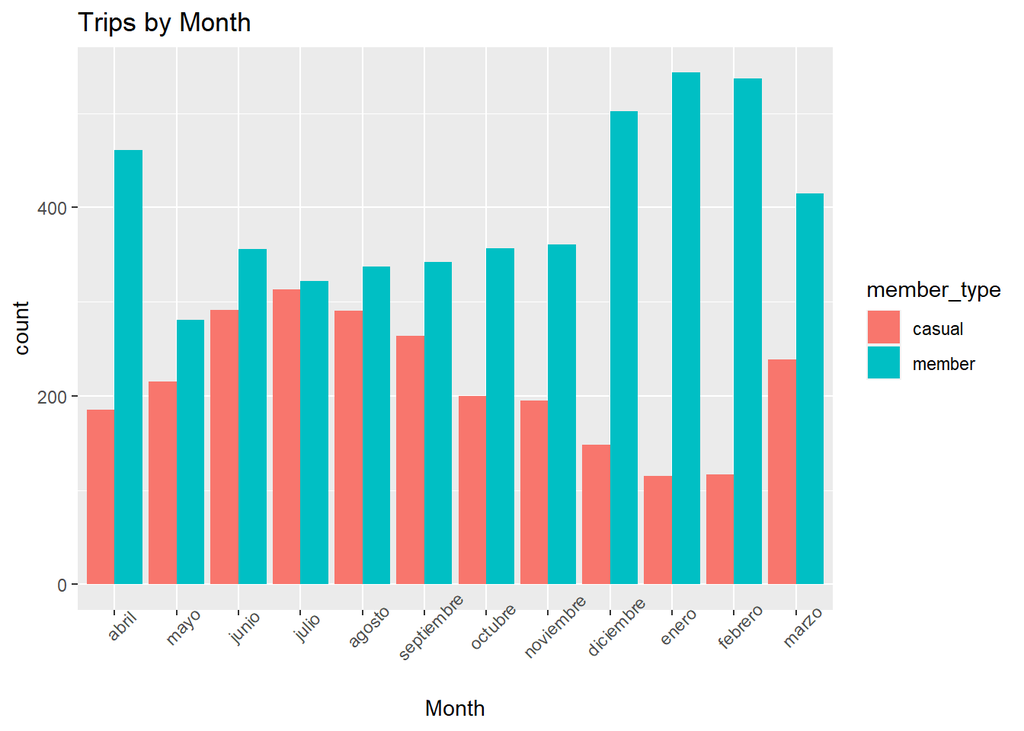

```r
#Factor is needed on Month column to order and display every label of the month
divvy_trip_data$Month <- factor(divvy_trip_data$Month, levels = unique(divvy_trip_data$Month))

#Plotting values based on month and filled by member_type
ggplot(data = divvy_trip_data) +
  geom_bar(mapping = aes(x = Month, fill = member_type), position=position_dodge()) +
  theme(axis.text.x = element_text(angle = 45)) +
  ggtitle("Trips by Month") +
  xlab("Month")
```

### Analysis by Week

Rides by day of the week are plotted. The barchart clearly shows that casual riders prefer riding on weekends, while members are constant regardless of day of the week. This might be because casual riders ride as a leisurely activity while members commute to work.

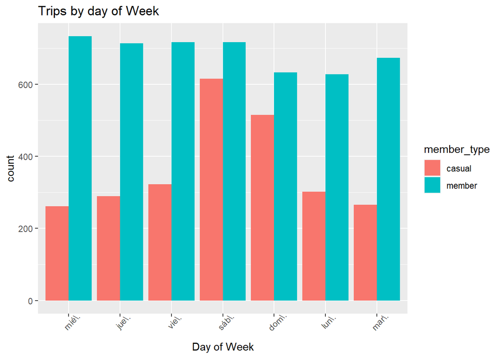

```r
#We do the same for days of the week
#Factor is needed on Month column to order and display every label of the month
divvy_trip_data$Weekday <- factor(divvy_trip_data$Weekday, levels = unique(divvy_trip_data$Weekday))


ggplot(data = divvy_trip_data) +
  geom_bar(mapping = aes(x = Weekday, fill = member_type), position=position_dodge()) +
  theme(axis.text.x = element_text(angle = 45)) +
  ggtitle("Trips by day of Week") +
  xlab("Day of Week")
```

### Distribution by type of bike

There are three types of bikes: classic, docked and electric. From the plot it is observed that although each kind of bike is preferred by members, the classic bikes show a greater difference than the other two types.

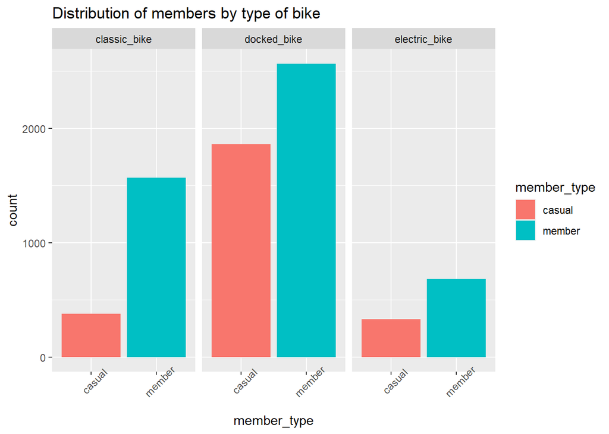

```r
#Distribution of members by type of bike
ggplot(data = divvy_trip_data) +
  geom_bar(mapping = aes(x = member_type, fill = member_type)) +
  facet_wrap(~rideable_type) +
  ggtitle("Distribution of members by type of bike") +
  theme(axis.text.x = element_text(angle = 45))
```

### Biketrip times

Calculating the average trip time of casual and member riders show that casual riders ride for more than double the time of member riders.

```r
#calculate time difference between rides
time_diff <- with(divvy_trip_data, difftime(time_end, time_start, units = "mins") )

#add column to dataframe
divvy_trip_data<- mutate(divvy_trip_data,trip_time = time_diff)

#means
#we make a subset to calculate mean trip time by member_type

df <- subset(divvy_trip_data, select = c(trip_time, member_type))


#We calculate the mean trip time for member riders
avg_trip_time_member = df %>%
  filter(member_type == "member") %>%
  summarise(Mean = mean(trip_time))

#move element from a row into a value
mean_trip_time_member = avg_trip_time_member[1]
rm(avg_trip_time_member)

#Do the same for casual members
avg_trip_time_casual = df %>%
  filter(member_type == "casual") %>%
  summarise(Mean = mean(trip_time))

#move element from a row into a value
mean_trip_time_casual = avg_trip_time_casual[1]
rm(avg_trip_time_casual)

print(paste("Mean time for casual riders: ", mean_trip_time_casual))
```

```
## [1] "Mean time for casual riders:  34.9681181959565"
```

```r
print(paste("Mean time for member riders: ", mean_trip_time_member))
```

```
## [1] "Mean time for member riders:  14.7833402575821"
```

### Limitations of my analysis

The data I worked with had certain limitations that should be addressed, for example, the dataset had no demographic data where I could apply an analysis to determine if member riders are mainly male or female, this would have made the analysis easier to perform and could have had an impact on the marketing strategy proposed. The data itself had no information about pay grades regarding the membership or no financial data regarding the users that hire the membership, this could have been useful to adjust the pay grade to make the membership more attractive to the specific salary range of our target audience.

### References

1. Information about how to get a sample size [link](https://www.statisticshowto.com/probability-and-statistics/find-sample-size/)
2. For the use of geosphere in the code: [link](https://andrewluyt.github.io/divvy-bikeshare/process-bikeshare-data.html)